# Numerical Integration: The Gamma Function

Let’s write a function that will estimate the integral of a function from points a to b, and estimate the value using one of the 3 methods of estimation (rectangle, trapezoid, or Simpson’s), with k number of cutpoints specified.

The 3 methods share the same k cutpoints, widths between points, and heights at each cutpoint.

```r
# Function to estimate an the value of the integral of function 'f' from
# points a to b using one of the 3 estimation methods.

# Number of cutpoints 'k' and 'method' must be specified.
integral_estimate <- function(f, a, b, k, method){
  # Stop if the number of 'k' cutpoints specified is less than 2
  if (k < 2){
    stop("Number of points 'k' must be at least 2")
  }
  # Width of boxes
  width <- (b - a) / (k - 1)
  # All cutpoints
  points <- seq(a, b, by = width)
  # Heights at each cutpoint
  heights <- f(points)
  # Estimate using the rectangle method
  if(method == "rectangle"){
    estimate <- width * sum(heights[1:k-1])
    # Estimate using the trapezoid method
  } else if(method == "trapezoid"){
    estimate <- (width / 2) * (heights[1] + heights[k] + 2*sum(heights[-c(1, k)]))
    # Estimate using the Simpson's rule method
  } else if(method == "simpson"){
    # If the number of cutpoints is odd, estimate using Simpson's rule
    if (k %% 2 != 0) {
      # Simpson's rule estimate if the number of cutpoints is 3
      if(k == 3){
      estimate <- (width / 3) * (heights[1] + heights[k] + 4*heights[k-1])
      # Simpson's rule estimate if the number of cutpoints is 5
      } else if(k == 5){
      estimate <- (width / 3) * (heights[1] + heights[k] + 4*sum(heights[seq(2, k-1, by = 2)]) + 2*heights[k-2])
      # Simpson's rule estimate if the number of cutpoints is greater than 5
      } else if(k > 5){
      estimate <- (width / 3) * (heights[1] + heights[k] + 4*sum(heights[seq(2, k-1, by = 2)]) + 2*sum(heights[seq(3, k-2, by = 2)]))
      }
      # If the number of cutpoints is even, can't use Simpson's rule
    } else if (k %% 2 == 0) {
      stop("Number of points 'k' must be odd to use Simpson's rule")
    }
    # Stop if the 'method' specified is not valid, and list valid methods.
  } else {
    stop('Please specify method "rectangle", "trapezoid", or "simpson"')
  }
  # Show the value of the estimate
  print(estimate)
}
```

Besides the inputs specified in the question, I also included the “method”, in which we can specify to use either “rectangle”, “trapezoid”, or “simpson” to estimate the intergral using their respective rule.

## 1.

Let’s use our function to estimate the integral for the exp(x) function from 0 to 1 and compare it to the algebraic results.

Let’s first check if the estimates of our function match what we should get using the rectangle and trapezoid for just 1 box (Note: Simpson’s rule will use 3 cutpoints instead of 2, since the number of boxes is Simpson’s rule is equal to (k - 1)/2 instead of k - 1 like the other methods).

```r
# Estimate using our function with the rectangle method
integral_estimate(exp, 0, 1, 2, "rectangle")
```

```
## [1] 1
```

```r
# Triangle rule for exp(x) from 0 to 1 with 2 cutpoints.
(1 - 0) * exp(0)
```

```
## [1] 1
```

```r
# Estimate using our function with the trapezoid method
integral_estimate(exp, 0, 1, 2, "trapezoid")
```

```
## [1] 1.859141
```

```r
# Trapezoid rule for exp(x) from 0 to 1 with 2 cutpoints.
1/2 * (exp(0) + exp (1))
```

```
## [1] 1.859141
```

```r
# Estimate using our function with the trapezoid method
integral_estimate(exp, 0, 1, 3, "simpson")
```

```
## [1] 1.718861
```

```r
# Simpson's rule for exp(x) from 0 to 1 with 3 cutpoints.
(1/6) * (exp(0) + 4*exp(1/2) + exp(1))
```

```
## [1] 1.718861
```

As we can see, our function yields the correct results for all 3 methods when using 1 box to estimate the value of the integral, so the function seems to be working as intended for 1 box estimation.

## 2.

Let’s now check if the estimates of our function match what we should get using the rectangle, trapezoid, and Simpson’s method using 2 boxes.

```r
# Estimate using our function with the rectangle method
integral_estimate(exp, 0, 1, 3, "rectangle")
```

```
## [1] 1.324361
```

```r
# Triangle rule for exp(x) from 0 to 1 with 3 cutpoints.
(1/2) * (exp(0) + exp(0.5))
```

```
## [1] 1.324361
```

```r
# Estimate using our function with the trapezoid method
integral_estimate(exp, 0, 1, 3, "trapezoid")
```

```
## [1] 1.753931
```

```r
# Trapezoid rule for exp(x) from 0 to 1 with 3 cutpoints.
(1/4) * (exp(0) + 2*exp (.5) + exp (1))
```

```
## [1] 1.753931
```

```r
# Estimate using our function with Simpson's method
integral_estimate(exp, 0, 1, 5, "simpson")
```

```
## [1] 1.718319
```

```r
# Simpson's rule for exp(x) from 0 to 1 with 5 cutpoints.
(1/12) * (exp(0) + 4*exp(1/4) + 2*exp(1/2) + 4*exp(3/4) + exp(1))
```

```
## [1] 1.718319
```

As we can see, our function yields the correct results for all 3 methods when using 2 boxes to estimate the value fo the integral, so the function seems to be working as intended for 2 box estimation.

## 3.

Let’s check what the true value of the integral of exp(x) from 0 to 1 is.

```r
# Integrate exp(x) function from 0 to 1
integrate(exp, 0, 1)
```

```
## 1.718282 with absolute error < 1.9e-14
```

Now let’s look at which of the methods yields the closest value to this when using k = 11 number of cutpoints.

```r
# Estimates of integral of exp(x) from 0 to 1 using all 3 methods with k = 11

# Estimate using our function with the rectangle method
integral_estimate(exp, 0, 1, 11, "rectangle")
```

```
## [1] 1.633799
```

```r
# Estimate using our function with the trapezoid method
integral_estimate(exp, 0, 1, 11, "trapezoid")
```

```
## [1] 1.719713
```

```r
# Estimate using our function with Simpson's rule method
integral_estimate(exp, 0, 1, 11, "simpson")
```

```
## [1] 1.718283
```

As we can see from our results, Simpson’s method is the closest to the true value for the integral of exp(x) from o to 1.

# Gamma Function

Let’s create our gamma function whose integral we wish to estimate.

```r
# Gamma function for any constant alpha
gamma_function <- function(x, alpha){
    (x^(alpha-1))*exp(-x)
}
```

## 1.

Now let’s plot our function for x from 0 to 20 to show the shape of the function, and from 0 to 10,000 to show the trend to infinity.

We will also look at the value of the integral for our function from 0 to 10,000 to estimate what it would be from 0 to infinity.

we will do this for alpha = 1 first.

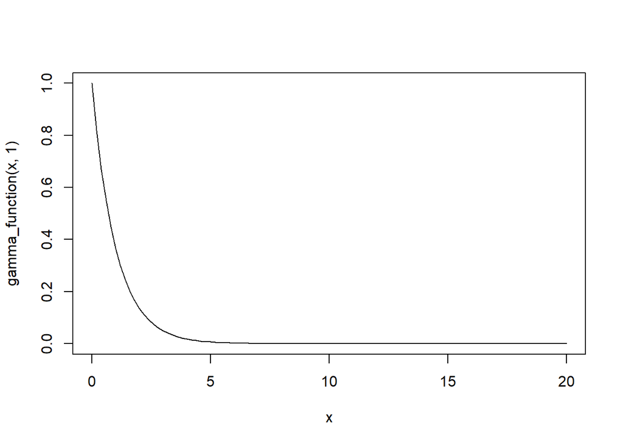

```r
# Plot of gamma function for x from 0 to 20 when alpha = 1
curve(gamma_function(x, 1), from = 0, to = 20)
```

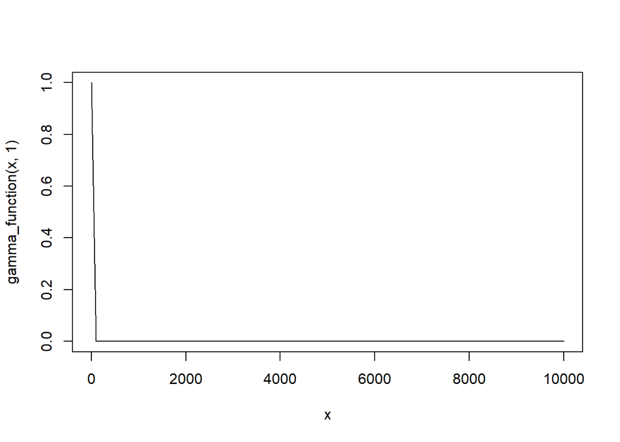

```r
# Plot of gamma function for x from 0 to 10,000 when alpha = 1
curve(gamma_function(x, 1), from = 0, to = 10000)
```

```r
# Integral of gamma function from 0 to 10,000 when alpha = 1
integrate(gamma_function, lower = 0, upper = 10000, alpha = 1)
```

```
## 1 with absolute error < 9.4e-08
```

As we can see, the value of the integral should be equal to 1.

Now let’s do the same plots for alpha = 2.

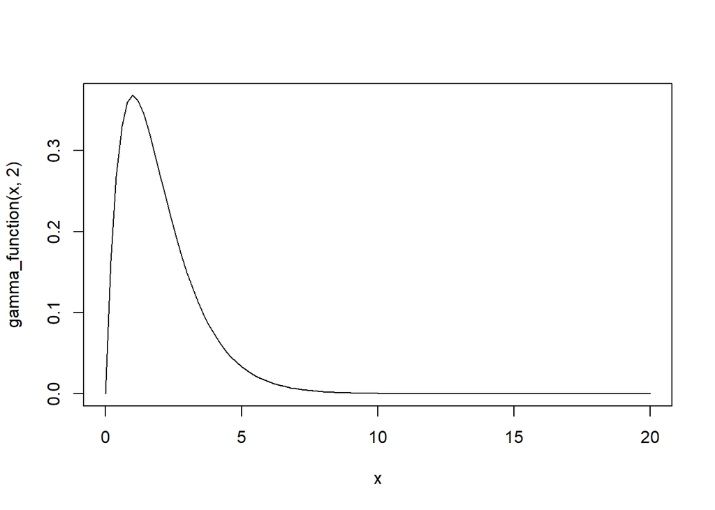

```r
# Plot of gamma function for x from 0 to 20 when alpha = 2
curve(gamma_function(x, 2), from = 0, to = 20)
```

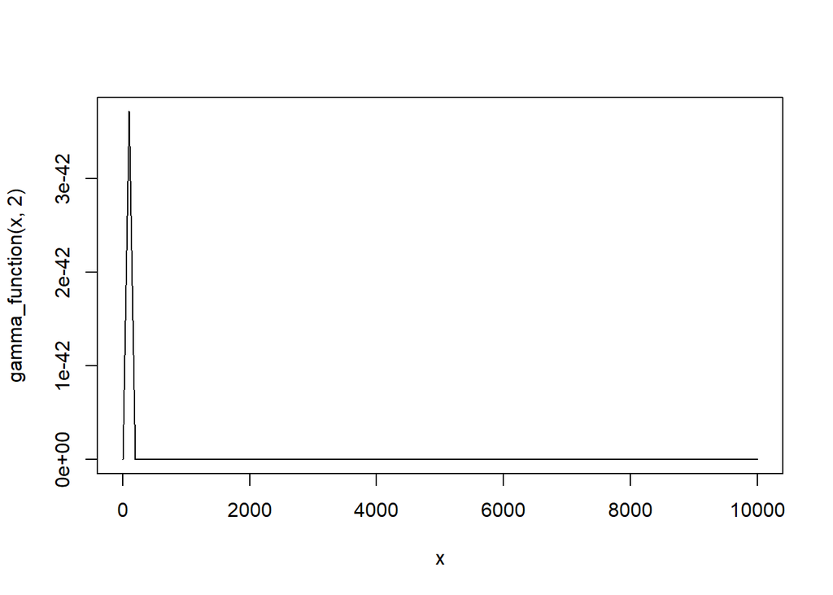

```r
# Plot of gamma function for x from 0 to 10,000 when alpha = 2
curve(gamma_function(x, 2), from = 0, to = 10000)
```

```r
# Integral of gamma function from 0 to 10,000 when alpha = 2
integrate(gamma_function, lower = 0, upper = 10000, alpha = 2)
```

```
## 1 with absolute error < 4.3e-06
```

As we can see, the value of the integral should be equal to 1 as well.

## 2.

Let’s use out function for integral estimation to estimate the integral from 0 to 10,000 (to approximate infinity) of our gamma function when alpha = 1.

We will use the trapezoid method for this, using 3 trapezoids (k = 4). Since we will be using this function to estimate the integral for the gamma function for different values of alpha, I adjusted my integral estimation formula so that the value of alpha can be included in the inputs.

```r
# Number of cutpoints 'k' and 'method' must be specified, 'alpha' is optional
integral_estimate_alpha <- function(f, a, b, k, method, alpha = "None"){
  # Stop if the number of 'k' cutpoints specified is less than 2
  if (k < 2){
    stop("Number of points 'k' must be at least 2")
  }
  # Width of boxes
  width <- (b - a) / (k - 1)
  # All cutpoints
  points <- seq(a, b, by = width)
  # Heights at each cutpoint if alpha is not specified
  if (alpha == "None"){
  heights <- f(points)
  # Heights at each cutpoint if alpha is specified
  } else {
  heights <- f(points, alpha)
  }
  # Estimate using the rectangle method
  if(method == "rectangle"){
    estimate <- width * sum(heights[1:k-1])
    # Estimate using the trapezoid method
  } else if(method == "trapezoid"){
    estimate <- (width / 2) * (heights[1] + heights[k] + 2*sum(heights[-c(1, k)]))
    # Estimate using the Simpson's rule method
  } else if(method == "simpson"){
    # If the number of cutpoints is odd, estimate using Simpson's rule
    if (k %% 2 != 0) {
      # Simpson's rule estimate if the number of cutpoints is 3
      if(k == 3){
      estimate <- (width / 3) * (heights[1] + heights[k] + 4*heights[k-1])
      # Simpson's rule estimate if the number of cutpoints is 5
      } else if(k == 5){
      estimate <- (width / 3) * (heights[1] + heights[k] + 4*sum(heights[seq(2, k-1, by = 2)]) + 2*heights[k-2])
      # Simpson's rule estimate if the number of cutpoints is greater than 5
      } else if(k > 5){
      estimate <- (width / 3) * (heights[1] + heights[k] + 4*sum(heights[seq(2, k-1, by = 2)]) + 2*sum(heights[seq(3, k-2, by = 2)]))
      }
      # If the number of cutpoints is even, can't use Simpson's rule
    } else if (k %% 2 == 0) {
      stop("Number of points 'k' must be odd to use Simpson's rule")
    }
    # Stop if the 'method' specified is not valid, and list valid methods.
  } else {
    stop('Please specify method "rectangle", "trapezoid", or "simpson"')
  }
  # Show the value of the estimate
  print(estimate)
}
```

Now that we have a new function for integral estimation, let’s use it for our estimate.

```r
# Integral estimate for gamma function with alpha = 1 from 0 to 10,000
# Using the trapezoid method with k = 4
integral_estimate_alpha(gamma_function, 0, 10000, 4, "trapezoid", alpha = 1)
```

```
## [1] 1666.667
```

## 3.

Using only 3 trapezoids, we got that the value of the integral is very large, which is incorrect given that we know the correct value is 1. Let’s try doing this estimation again with different values of k until we approach 1.

```r
# Integral estimate for gamma function with alpha = 1 from 0 to 10,000
# Using the trapezoid method with k = 10,000
integral_estimate_alpha(gamma_function, 0, 10000, 10000, "trapezoid", alpha = 1)
```

```
## [1] 1.081993
```

```r
# Integral estimate for gamma function with alpha = 1 from 0 to 10,000
# Using the trapezoid method with k = 1,000,000
integral_estimate_alpha(gamma_function, 0, 10000, 1000000, "trapezoid", alpha = 1)
```

```
## [1] 1.000008
```

```r
# Integral estimate for gamma function with alpha = 1 from 0 to 10,000
# Using the trapezoid method with k = 50,000,000
integral_estimate_alpha(gamma_function, 0, 10000, 50000000, "trapezoid", alpha = 1)
```

```
## [1] 1
```

We can see that as our number of k cutpoints becomes larger, the value of our estimate gets closer to the true value of 1, with it being 1 at k = 50,000,000.

## 4.

Using our integral estimation function with k = 50,000,000, let’s estimate the same integral for the gamma function for other integer values of alpha.

We will do this for alpha = 2, 3, 4, 5, and 6.

```r
# Integral estimate for gamma function with alpha = 2
integral_estimate_alpha(gamma_function, 0, 10000, 50000000, "trapezoid", alpha = 2)
```

```
## [1] 1
```

```r
# Integral estimate for gamma function with alpha = 3
integral_estimate_alpha(gamma_function, 0, 10000, 50000000, "trapezoid", alpha = 3)
```

```
## [1] 2
```

```r
# Integral estimate for gamma function with alpha = 4
integral_estimate_alpha(gamma_function, 0, 10000, 50000000, "trapezoid", alpha = 4)
```

```
## [1] 6
```

```r
# Integral estimate for gamma function with alpha = 5
integral_estimate_alpha(gamma_function, 0, 10000, 50000000, "trapezoid", alpha = 5)
```

```
## [1] 24
```

```r
# Integral estimate for gamma function with alpha = 6
integral_estimate_alpha(gamma_function, 0, 10000, 50000000, "trapezoid", alpha = 6)
```

```
## [1] 120
```

- Based on the estimates of these integrals at different levels of alpha, we can see the following pattern:

Integral of gamma (alpha = 2) = 1 = 1x1 = 1*[Integral of gamma (alpha = 1)]

Integral of gamma (alpha = 3) = 2 = 2x1 = 2*[Integral of gamma (alpha = 2)]

Integral of gamma (alpha = 4) = 6 = 3x2 = 3*[Integral of gamma (alpha = 3)]

Integral of gamma (alpha = 5) = 24 = 4x6 = 4*[Integral of gamma (alpha = 4)]

Integral of gamma (alpha = 6) = 120 = 5x24 = 5*[Integral of gamma (alpha = 5)]

- This can be expressed the following way, for any positive value of a:

Integral of gamma (alpha = a + 1) = a*[Integral of gamma (alpha = a)]